# Open Science and Reproducible Research in R

Lecture Series Feedback and Evaluation for 2023

Ernest Guevarra

2023-03-23

# List of Figures

- 3.1 Number of commits per week by IHTM class

# 1 Introduction

This report provides my feedback, comments, and insight from a self-evaluation of the [Open Science and Reproducible Research in R Lecture Series](https://oxford-ihtm.io/open-reproducible-science) as the lecture series organiser and facilitator. This report focuses on evaluating the lecture series based on its two main learning objectives:

1. Provide students with an introductory/foundational understanding and practical skills in using [R](https://cran.r-project.org) for data management and analysis; and,
2. Provide students with an introductory/foundational understanding and practical skills in open science and reproducible research using R.

In addition, this report provides insight and perspective on the evolution of the lecture series since its inception and introduction to the MSc in International Health and Tropical Medicine course in 2022 and highlights impacts of changes implemented over the years in relation to the two main objectives stated above.

## 1.1 Background on changes in the lecture series over time

Following were the major changes implemented in this lecture series since its initiation in 2022.

- The lecture series is required for all students in the MSc for 2023 compared to it being a choice for students to participate during its implementation year.
- The lecture series has been expanded to 11 sessions compared to 6 sessions in 2022. This expansion allowed for the specific R learning components of the previous series to be made into their own sessions (5 sessions) at the start of the series to address the first main learning objective and the original 6 sessions followed thereafter to address the second main learning objective.
- Coding assignments were still delivered and managed through [GitHub Classroom](https://classroom.github.com) using an education GitHub account via Oxford that provides features to create, manage, and grade/review coding assignments. The main difference now is that only one coding assignment was provided which the students worked on starting in session 2 up to session 8 (7 sessions) compared to 2 assignments which students covered in 2 session (about 1 session per assignment).
- R laboratory sessions outside of the 11 sessions were also provided as with previous year. However, all R laboratory sessions were one-on-one 30-minute sessions all throughout compared to initial group sessions (up to 3 students for 30 minutes) throughout the duration of the lecture series in the inaugural year and shifted to one-on-one 30 minute sesssions after the lecture series was completed. R laboratory sessions are sessions that the students can book if they felt they needed more informtion/discussion regarding a topic presented in class. These sessions have also been used by students who have missed a class session and wanted to catch up with the topic that was discussed then.
- A handbook was created specifically for this year’s lecture series which was accessible both as an online handbook (see https://oxford-ithm/ihtm-handbook) and as a downloadable PDF (https://oxford-ihtm.io/ihtm-handbook/ihtm-handbook.pdf) or as an Ebook (https://oxford-ihtm.io/ihtm-handbook/ihtm-handbook.epub). The aim of the handbook is to serve as a reference for students on basic and overview types of topics that may help them currently or in the future when trying to apply the skills they’ve learned from this lecture series.
- A three-session (one month period) [hackathon](https://github.com/OxfordIHTM/ihtm-hackathon-2023) which was conducted in the period of the last three sessions of the lecture series. The hackathon was designed more as a problem-based learning exercise to culminate the entire lecture-series. The hackathon offered a challenge that would require the students to put together all the R coding and open science/reproducible research concpets and skills they have learned and/or are learning so far to address a real-life problem/topic with actual research data. Within the three face-to-face sessions, topics relevant to the problem were presented and discussed whilst the students were working through their problem sets. This hackathon was a unique feature of this year’s edition of the lecture series.
- A [discussion board](https://github.com/orgs/OxfordIHTM/discussions) specific to the lecture series was initiated. The discussion board was primarily a forum to address and discuss very specific questions and/or topics that the students may have. It was also a means for the lecture series presenter/facilitator to share solutions/answers to the coding assignments and exercises. Whilst the discussion board was also there in the inaugural year, this year’s iteration had a much clearer usage and purpose and was actively used.
- Asynchronous code review process using git and GitHub functionalities. Whilst these functionalities were already available and usable in the inaugural year, this year saw the full use of this feature.

# 2 Evaluation approach

In this evaluation, I use two sources of information to guide my evaluation of the lecture series. First, I utilise the available user data via the lecture series’ [GitHub](https://github.com/OxfordIHTM) platform to gain insight into how the students engaged and interacted with the topics, exercises, and activities. Specifically, I used the **commit** and **push**See https://github.com/git-guides/git-commit and https://github.com/git-guides/git-push, **pull**See https://github.com/git-guides/git-pull, and **merge**See https://www.git-tower.com/learn/git/commands/git-merge metrics of the whole class to characterise as objectively as possible the students’ level of engagement with the topics discussed while at the same time provides an assessment of the students’ ability to demonstrate and apply the practical skills presented in class.

## 2.1 The git commit and push, pull request, and merge process metrics

A `git commit` is a fundamental operation in the Git version control system, which is used to save changes made to a repository. When you make changes to files in a Git repository, you can create a commit to record those changes. A git commit is essentially a snapshot of the state of the repository at a particular point in time. It includes a unique identifier (called a “hash”) that identifies the commit, as well as metadata such as the author, date, and commit message. The commit message is a brief description of the changes made in that commit, which helps other developers understand the purpose of the commit. When a `git commit` is created, a permanent record of one’s changes are recorded, which can be used to track the history of the repository and collaborate with other developers. `git push`, on the other hand, uploads the commits made in the local repository to a remote repository, such as GitHub, GitLab, or Bitbucket. When you push changes to a remote repository, git compares the differences between your local repository and the remote repository, and then sends the new changes to the remote repository. This allows other developers working on the same project to see and access your changes. By this characteristic, students’ `git commit and push` is a good record of students’ work during the lecture series and a good baseline indicator of their ability to write code and script (regardless of whether this code is syntactically and operationally correct).

A `git pull request` is a feature that allows developers (in this case students) to propose changes to a codebase hosted on a git repository. It enables developers/students to share their changes with other members of the team and solicit feedback or approval before merging their changes into the main branch. When a developer/student makes changes to a branch in their local repository, they can create a pull request to request that those changes be pulled into another branch or repository. The pull request shows the differences between the two branches, and allows other developers/students or myself (the facilitator) to review the changes and leave comments or suggestions for improvement.

In the case for the lecture series, once the pull request is submitted, it is reviewed by myself, commenting on the changes or requesting further modifications. The pull request was also used to trigger automated tests to ensure that the proposed changes do not introduce any errors or regressions. The `git pull request` is a good indicator of a students’ confidence in their code and their ability to check their own code locally which is a one-step higher order of knowledge and understanding of both R coding and use of git as a tool for reproducible science.

Finally, a `git merge` takes place once I approve the student’s code in their `pull request`. The `pull request` can be merged into the target branch, allowing the changes to become part of the codebase. If not, the developer can make further modifications and submit a new pull request. `git merge` of a pull request is the highest level of accomplishment for the students as this means they were able to create R code that were syntactically correct while at the same time R code that actually outputs/produces the intended/required output. A merged pull request also means that students were able to engage with the review process demonstrating their ability to use git as a tool for reproducible science.

## 2.2 The manual code review and subjective assessment process

The **commit**, **push**, and **merge** metric were then corroborated/triangulated with my own qualitative and subjective observations during my interactions with the students during the lecture sessions, R laboratory sessions, and other interactions via the GitHub review process and discussion board.

I deemed this quantitative and qualitative/objective and subjective approach to this evaluation the most appropriate approach to assess the performance of the lecture series in reaching its learning objectives and reflects much closely and realistically what has transpired throughout the lecture series process.

# 3 Evaluation results

## 3.1 git metrics

Table 3.1 presents overall git metrics for IHTM class 2022 and 2023.

Table 3.1: Overall git metrics for 2022 and 2023

| IHTM Class | No. of students | No. of commits | No. of pull requests | No. of merged pull requests | Commits rate | Pull request rate | Merge rate |
| --- | --- | --- | --- | --- | --- | --- | --- |
| class-2022 | 16 | 111 | 5 | 4 | 6.94 | 1.39 | 1.73 |
| class-2023 | 23 | 728 | 33 | 19 | 31.65 | 0.96 | 1.67 |

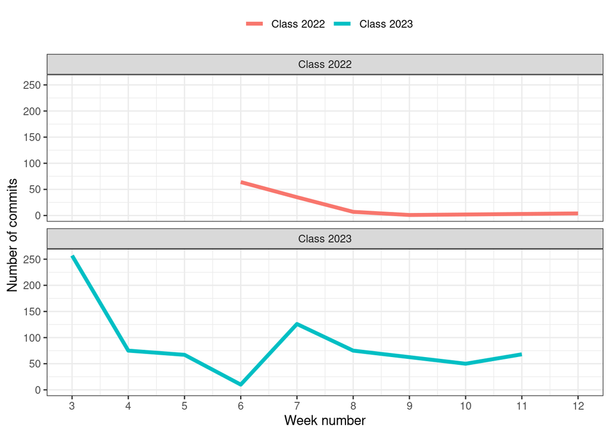

Figure 3.1: Number of commits per week by IHTM class